# Mouse ovary spatial transcriptomics (tutorial)

### Spatial Cell-Type Co-localization

In a UMAP or DotPlot, cell types are compared transcriptomically. Spatial co-localization asks a complementary question: **which cell types are physically adjacent in the tissue?** This is a direct readout of tissue architecture and validates annotations using spatial logic rather than transcriptomic similarity.

For the mouse ovary, we expect a concentric follicle structure: oocyte → cumulus → mural granulosa → theca

Each cell type should be most enriched in the spatial neighborhood of the expected adjacent type.

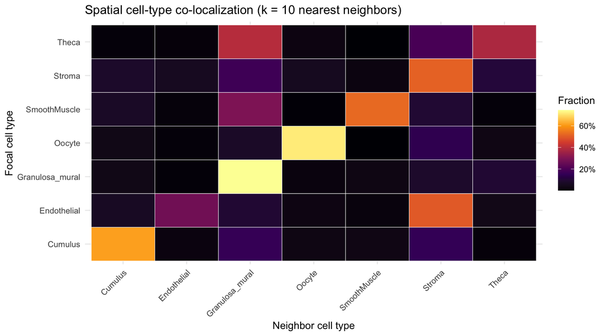

```r
if (!is.null(obj$x_coord)) {
  meta <- obj@meta.data
  ct   <- meta$cell_type
  coords_all <- as.matrix(meta[, c("x_coord", "y_coord")])

  # For speed: subsample to max 8,000 beads if dataset is large
  n_total <- nrow(coords_all)
  if (n_total > 8000) {
    set.seed(42)
    sub_idx <- sample(n_total, 8000)
  } else {
    sub_idx <- seq_len(n_total)
  }

  coords_sub2 <- coords_all[sub_idx, ]
  ct_sub      <- ct[sub_idx]
  ct_levels   <- sort(unique(ct_sub))

  # Build spatial kNN (k = 10) using a simple Euclidean distance approach
  # (avoids external package dependency)
  k <- 10
  coloc_mat <- matrix(0, nrow = length(ct_levels), ncol = length(ct_levels),
                      dimnames = list(ct_levels, ct_levels))

  # Batch kNN: for each focal bead, find k nearest neighbors
  dist_sq <- function(a, B) rowSums(sweep(B, 2, a, "-")^2)

  for (i in seq_along(sub_idx)) {
    dists  <- dist_sq(coords_sub2[i, ], coords_sub2[-i, ])
    nn_idx <- order(dists)[seq_len(k)]
    nn_cts <- ct_sub[-i][nn_idx]
    focal  <- ct_sub[i]
    for (nc in nn_cts) {
      coloc_mat[focal, nc] <- coloc_mat[focal, nc] + 1
    }
  }

  # Row-normalise to fractions
  coloc_frac <- sweep(coloc_mat, 1, rowSums(coloc_mat), "/")

  # Melt and plot
  coloc_df <- as.data.frame(as.table(coloc_frac))
  colnames(coloc_df) <- c("focal", "neighbor", "fraction")

  ggplot(coloc_df, aes(neighbor, focal, fill = fraction)) +
    geom_tile(colour = "white") +
    scale_fill_viridis_c(option = "B", labels = scales::percent_format(1)) +
    theme_minimal(base_size = 11) +
    theme(axis.text.x = element_text(angle = 45, hjust = 1)) +
    labs(
      title = "Spatial cell-type co-localization (k = 10 nearest neighbors)",
      x = "Neighbor cell type", y = "Focal cell type", fill = "Fraction"
    )
}
```

> **Check your understanding — Cell Typing**

> One cluster uniquely co-expresses *Cyp17a1* (a cytochrome P450 enzyme in androgen biosynthesis) and *Lhcgr* (the LH/hCG receptor). Which cell type does this represent, and why is this co-expression physiologically critical?
> 1. Granulosa (mural) — they convert androgens to estrogen and carry the LH receptor to respond to the preovulatory surge
> 2. Theca cells — they synthesize androgens (*Cyp17a1*) under LH stimulation (*Lhcgr*), supplying the substrate that granulosa cells aromatize into estrogen: the “two-cell, two-gonadotrophin” model of estrogen production
> 3. Cumulus cells — they surround the oocyte and express steroidogenic enzymes to support oocyte maturation
> 4. Oocytes — they direct steroidogenesis in surrounding somatic cells through paracrine factors

> **Answer: B** — This is the textbook *two-cell two-gonadotrophin* model: LH acts on theca cells (via *Lhcgr*) to drive androgen synthesis (*Cyp17a1* → androstenedione); FSH acts on granulosa cells to aromatize those androgens into estradiol (via *Cyp19a1*). The co-expression of *Cyp17a1* and *Lhcgr* is the definitive molecular signature of theca cell identity.